# OpenStreetMaps Project

## Introduction

The project I am going to develop its about auditing, cleaning and enhancing a dataset containing a region of the world of my choice. In my case I decided to work with my hometown Madrid. The file is 600MBs. The size of the file has posed a problem during the realization of the project, that is why in the last parts of the project we have reduced the size of the dataset we will be working on. The project is going to have three specific parts:

- Auditing our data : in here we will look all over our data to find where can it be enhanced or fixed
- Treating/Enhancing data : the enhancements and fixes found in the previous part will be applied here
- Analyzing our data : Once we have our data stored in the main database In each of them we will be applying the different concepts we have learned during the course as well as applying different previous knowledge. First we are going to reproduce the quizzes we made during the mongodb case study. We are going to use this quiz to start improving the dataset

```python
#!/usr/bin/env python
# -*- coding: utf-8 -*-
import xml.etree.cElementTree as ET
import pprint
from collections import defaultdict
import re
import codecs
import json
import pprint
import phonenumbers
import requests
import signal
import pymongo
from pymongo import MongoClient
import matplotlib.pyplot as plt
```

## Auditing our data

In this part we are going to look over our data and try to find as many enhancements or fixes as we can in order to be able to deliver a much better and complete dataset. Mainly we are going to take a look to the address fields and try to stablish rules for a future normalization of the streettypes as well as phones and any other thing we can come up with.

```python
# ================================================== #
#               Helper Functions                     #
# ================================================== #
def get_element(osm_file):
    """Yield element if it is the right type of tag"""
    # This is the function we are going to use to iterate through our dataset
    # so we can avoid storing it all in memory
    context = ET.iterparse(osm_file, events=('start', 'end'))
    _, root = next(context)
    for event, elem in context:
        if event == 'end':
            yield elem
            root.clear()
```

```python
# The regular expression used  to detect the street type
street_type_re = re.compile(r'^\b\S+\.?', re.IGNORECASE)
problemchars = re.compile(r'[=\+/&<>;\'"\?%#$@\,\. \t\r\n]')
# The array of expected street types
EXPECTED = ["Calle", "Avenida", "Plaza", u"Autov\xeda",
            "Carretera", "Camino", "Via", u"Traves\xeda", "Ronda",
           "Puerta", "Plaza", "Paseo", u"Pol\xedgono", "Glorieta",
            u'Callej\xf3n', u'V\xeda']
```

We have modified the regular expression so it gets the first word instead of the last one. Given that in spanish the street types is written at the start of the string instead of in English that, as you may know, at the end. Given that our dataset is in Spanih we are facing the problem of the codification of our data because some of it is in unicode and others in string, so I decided to code everything in unicode so it can have an standard.

```python
# This functon is in charge creating a set of street types
# that are not expected
def audit_street_type(street_types, street_name):

    m = street_type_re.search(street_name)
    if m:
        street_type = m.group()
        if street_type not in EXPECTED:


            # street_types[street_type].add(type(street_name))
            street_types[street_type].add(street_name)

# this is a simple function to detect a street
def is_street_name(elem):
    return (elem.attrib['k'] == "addr:street")
```

```python
# Define a set to store the street types
street_types = defaultdict(set)
# Loop used for getting to the attribute we want
for event, elem in enumerate(get_element("Madrid.osm")):
    if elem.tag == "node" or elem.tag == "way":
        for tag in elem.iter("tag"):
            if is_street_name(tag):
                audit_street_type(street_types, tag.attrib['v'])
```

```python
# street_types
# I commented the line so there are not that many lines
```

After some auditing of the data I build the Expected array with the street types we have selected to be the right ones. Once we got the ones that are right we need to divide the rest into two different groups:

1. The street types that are wrongly written
2. The rest of the street types are really part of the street

Now that we have identified the two different types of data we are facing we have to parse all of the data to string. After trying to parse all data to string we realized that we couldnt do it given the fact that string doesnt manage the special ascii characters. So we are going to try to parse everithing in unicode with utf-8 coding. After having specified the way we are going to treat the data we move to the next step

### Treating the data

In order to start fixing the data, first we are going to create a dictionary with the elements that are wrongly written. Now that we are aware of the different fixes we are goig to do to our data. We will start by normalizing our data as we learned during the course.

```python
EXPECTED = ["Calle", "Avenida", "Plaza", u"Autov\xeda",
            "Carretera", "Camino", "Via", u"Traves\xeda", "Ronda",
           "Puerta", "Plaza", "Paseo", u"Pol\xedgono", "Glorieta",
            u'Callej\xf3n', u'V\xeda']
types_to_fix = {"AUTOP.":u'Autopista', "AUTOVIA":u'Autovia',
            "AV.":u'Avenida', "AV":u"Avenida", "AVDA.":u"Avenida",
            "AVDA":u"Avenida", "AVENIDA":u"Avenida",
            "Av.":u"Avenida", "Avda.":u"Avenida", "Avda":u"Avenida",
            "Avenidad":u"Avenida",
            "C/":u"Calle", "CALLE":u"Calle", "CL":u"Calle",
            "Call":u"Calle", "calle":u"Calle",
            "CARRERA":u"Carretera", "CARRETERA":u"Carretera",
            "CR":u"Carretera", "CRTA":u"Carretera", "CRTA.":u"Carretera",
            "Carrterera":u"Carretera", "Ctra":u"Carretera",
            "Ctra.":u"Carretera",
            "GLORIETA":u"Glorieta", "Joaquin":u"Joqu\xedn",
            "Jose":u"Jos\xe9",
            u"Pol\xef\xbf\xbd\xef\xbf\xbdgono":u"Pol\xedgono",
            u"Poligono":u"Pol\xedgono", "POLIGONO":u"Pol\xedgono",
            "Pz":u"Plaza", "Pza.":u"Plaza", "PLAZA":u"Plaza",
            "plaza":u"Plaza",
            "PASEO":u"Paseo", "Pasage":u"Pasaje", "ZONA":u"Zona",
            "zarzuela":u"Zarzuela", "montecarmelo":u"Montecarmelo"
            }
CREATED = [ "version", "changeset", "timestamp", "user", "uid"]
```

During the realization of the previous codeblock we found that some of the data was misplaced and there was a node that was from Reus Tarragona. Which is a city that is around 400 Km NorthEast Madrid, and obviously is not supposed to be in our dataset. In order to have a coherent dataset we proceed to erase this node

```python
def format_phone(phone):
    # for the formatting of the phones I decided to use
    # an adaptation of a Google library for phone formatting
    parsed_number = phonenumbers.parse(phone,"ES")
    if phonenumbers.is_valid_number(parsed_number):
        final_phone = phonenumber.format_number(parsed_number,phonenumbers.PhoneNumberFormat.E164)
        return final_phone
    else:
        return None

def check_cp(node):
    if "address" in node:
        if "postcode" not in node["address"].keys():
            pass

    return node
```

```python
# function in charge of creating a json object / dictionary with all the data
def shape_element(element):
    node = {}
    if element.tag == "node" or element.tag == "way":
        node["type"] = element.tag
        attributes =  element.attrib
        for elem in attributes:
            if elem in CREATED:
                if "created" not in node:
                    node["created"] = {}
                node["created"][elem] = attributes[elem]
            elif elem == "lon" or elem == "lat":
                if "pos" not in node:
                    node["pos"] = [0,0]
                if elem == "lon":
                    node["pos"][1] = float(attributes[elem])
                else:
                    node["pos"][0] = float(attributes[elem])
            else:
                node[elem] = attributes[elem]

        for child in element:
            if child.tag == "tag":
                attributes = child.attrib
                if not problemchars.search(attributes["k"]):
                    if attributes["k"].startswith("addr:"):
                        adr = attributes["k"][5:]
                        if ":" not in adr:
                            if "address" not in node:
                                node["address"] = {}
                            node["address"][adr] = attributes["v"]
                    elif ":" in attributes["k"]:
                        pos = attributes["k"].index(":")
                        keys = attributes["k"]
                        if keys[:pos] in node:
                            if keys[pos+1:] == "phone":
                                attributes['v'] = format_phone(attributes['v'])
                            if attributes['v'] != None:
                                node[keys[:pos]][keys[pos+1:]] = attributes["v"]
    node = check_cp(node)
    return node
```

```python
# this functionis the one in charge of savis the data generated in shape_element, concatenate it
# all and save it in a JSON file for future use
def process_map( file_in = "Madrid.osm", pretty = True):
    # You do not need to change this file
    file_out = "Madrid.json"
    data = []
    firstline = True
    with open(file_out, 'w') as outfile:
        for _, element in enumerate(get_element("Madrid.osm")):
            el = shape_element(element)
            if el:
                data.append(el)
                if firstline:
                    print el
                    firstline = False
        json.dump(data, outfile, indent=4, sort_keys=True, separators=(',', ':'))
    return data
```

```python
#data = process_map()
len (data)
```

```
2328967
```

### Enhancing our data

Once we have the actual json document we start to look for different enhancements to our data. For that, we need to start going through our data and try to find things we could add or normalize like telephone numbers or cities. Given that our dataset not only comprises Madrid but the surrounding cities. For the main enhancement first we have to check who meany addresses are mising as well as coordinates. For that wejust need somo simple functions to count the number of elements missing.

```python
# From now on we can work with the json file that has all the
# information of the osm file with the telephone already formatted
# also we evade re executing the previous parts to avoid unnecessary execution time
with open('Madrid.json') as data_file:
    data = json.load(data_file)
```

```python
# this returns the number of elements that doesnt posess coordinates
# and also return the number of elements without coordinates but with addresss
def num_pos(data, nopos, siadr):
    if "pos" not in data.keys():
        nopos += 1
        if "address" in data.keys():
            siadr += 1
    return nopos, siadr
# this returns the number of elements that doesnt posess address
# and also return the number of elements without address but with coordinates
def num_adr(data, noadr, sipos):
    if "address" not in data.keys():
        noadr += 1
        if "pos" in data.keys():
            sipos += 1
    return noadr, sipos
```

```python
nopos = 0
siadr = 0
for elem in data:
    nopos, siadr = num_pos(elem, nopos, siadr)
```

```python
print "Elements in our data that doesnt have coordinates is: " + str(nopos)
print "and from those elements that have adresses are: " + str(siadr)
# Here the variable nopos gives the number of element that
# doesnt have a position
# And the siadr variable states the number of those that have an
# address
```

```
Elements in our data that doesnt have coordinates is: 310311
and from those elements that have adresses are: 29289
```

With this output we see the number of position values we can fill with the information of the address. For that we are going to use a geocoding API to fill those blanks. Now we are going to find out how many cases we have in reverse

```python
noadr = 0
sipos = 0
for elem in data:
    noadr, sipos = num_adr(elem, noadr, sipos)
```

```python
# Now we print the variables
print "Elements in our data that doesnt have addresses is: " + str(noadr)
print "and from those elements that have coordenates are: " + str(sipos)
```

```
Elements in our data that doesnt have addresses is: 2270592
and from those elements that have coordenates are: 1989570
```

Now that we have found some part of our data that could be enhanced we need to find out how to enhance it. In my previous job we worked with somethin called geocoding. Which is a technology capable returning a set of coordinates given an address, also the reverse geocoding exists which does the same in reverse. So once I knew of a tool that I could apply to this project I decided to find for an API that could suit my necesities:

Thanks to some research we have found to major goecoding APIs:

- Google Geocoding API with 2500 a day
- Mapquest 10.000
- Geocode Unilimited requets

```python
# We make our first try to see how the answers are delivered
url = "https://geocode.xyz/{data}?geoit=json"
r = requests.get(url.format(data="castellana 130 madrid"))
get_json(r)
```

```
{u'latt': u'40.45022',
 u'longt': u'-3.69014',
 u'standard': {u'addresst': u'PS CASTELLANA',
  u'city': u'Madrid',
  u'confidence': u'0.80',
  u'postal': {},
  u'prov': u'ES',
  u'stnumber': u'130'}}
```

```python
adr_dict ={"city":"city",
           "staddress":"street",
           "postal":"postcode", # careful this is a list
          "stnumber":"housenumber"}
pos_dict = {"latt":"pos", # This must be the first position [0]
           "longt":"pos"} # This must be the second position [1]
```

```python
# this function takes returns the json produced by the http response
def get_json(r):
    json_data =  r.text
    json_data = json.loads(json_data)
    return json_data
```

```python
# This is the modified version of the num_pos function, in this case it returns True only if the json package
# doesnt have pos key but has a address one
def check_pos(data):
    if "pos" not in data.keys():
        if "address" in data.keys():
            return True
    return False
# This is the modified version of the num_adr function, in this case it returns True only if the json package
# doesnt have adress key but has a pos one
def check_adr(data):
    if "address" not in data.keys():
        if "pos" in data.keys():
            return True
    return False
```

```python
# this function is the one in charge of filling the coordinates in the pos key.
#Recieves the data variable and the url needed to make the request
def fix_pos(data, url):
    #first build the necessary data to use the API
    if "pos" not in data.keys():
        if "address" in data.keys():
            street = ""
            if "street" in data["address"].keys():
                print "a"
                street += data["address"]["street"]
                if "housenumber" in data["address"].keys():
                    street += " " + data["address"]["housenumber"]
                if "city" in data["address"].keys():
                    street += " " + data["address"]["city"]
    # Once we have the street variable filled we format it into the url
    # and send the https request
            r = requests.get(url.format(data=street))
            json_data = get_json(r)
            if "latt" in json_data.keys() and "longt" in json_data.keys():
                # And now we fill the empty pos key with the information gathered by the API request
                data["pos"] = [json_data["latt"], json_data["longt"]]
    return data
# this function is the one in charge of filling the adress in the address key.
#Recieves the data variable and the url needed to make the request
def fix_adr(data, url):
    if "address" not in data.keys():
        if "pos" in data.keys():
            # Here we form the coord variable wich has the info needed for the geocoding /http request
            coord = "{lat},{lon}".format(lat=data["pos"][0], lon=data["pos"][1])
            r = requests.get(url.format(data=coord))
            json_data = get_json(r)
            # And once we have recieved the data it is inputted in the data variable
            data["address"] = {}
            for key in adr_dict:
                if key in json_data:
                    data["address"][adr_dict[key]] = json_data[key]
    return data
```

```python
def save_data(data, file_out):
    with open(file_out, 'w') as outfile:
        json.dump(data, outfile, indent=4, sort_keys=True, separators=(',', ':'))
```

```python
len(data)
```

```
2328967
```

```python
# this function was developed to create an alarm and save the data every hour
def signal_handler(signum, frame):
        print "One hour has passed, time to save"
        save_data(data_treated, "Madrid_V1.json")
        signal.alarm(3600)

#we set up the handler as well as the alarm
signal.signal(signal.SIGALRM, signal_handler)
signal.alarm(3600)
firstline = True
data_treated = []
# this is the loop in charge of fixing and returning the whole data fixed
for i in range(len(data)):
    #Given the size of the dataset and we had to handle possible errors so the loop can still working
    if i == 100:
        break
    try:
        if check_adr(data[i]):
            data[i] = fix_adr(data[i],url)
    except Exception as e:
        print "Error in line: " + str(i)
        save_data(data_treated, "Madrid_vError.json")
        print e
    try:
        if check_pos(data[i]):
            data[i] = fix_pos(data[i], url)
    except Exception as e:
        print "Error in line: " + str(i)
        save_data(data_treated, "Madrid_vError.json")
        print e
    data_treated.append(data[i])

# finally once the loop is over the whole data is saved
save_data(data_treated, "Madrid_v1.json")
```

```
One hour has passed, time to save
One hour has passed, time to save
```

```python
len(data_treated)
```

[output not shown]

```python
# given that we had to stop earlier we saved our data with this call
save_data(data_treated, "Madrid_V1.json")
```

## Analyzing our data

Now we have our data in json format, cleaned and enhanced we are prepared to insert it into our MongoDB databes, which is the one we decided to work with. Once the data has been inserted we will do different database calls so we can show different statistics of our data. This statistics include bargraphs all thanks to the use of the aggregate funnction which allows you a great capabilities of data handling.

```python
# Now we just need to save our cleaned and enhanced data in mongoDB
result = db.project.insert_many(data_treated)
```

```python
# we connect and move to the right database and collection
connection = MongoClient()
db = connection.openstreetmaps
```

```python
db.project.count()
```

```
256358
```

As we can see the database has been filled with the formatted data and now it can be accessed through the pymongo function calls without the need of storing all the data in memory.

Now we are going to get some useful statistics with the data by using function calls to mongoDB

```python
# helper function to print the data with the provided databese and the pipeline
def print_data(db, pipeline):
    return [doc for doc in db.project.aggregate(pipeline)]
```

```python
print_data(db, [{"$group":{"_id":"$created.user", "count": {"$sum": 1}}},{"$sort": {"count":-1}},{"$limit":1}])
```

```
[{u'_id': u'jamesks', u'count': 38598}]
```

Here we can see one of the uses in aggregate in which we can now see who has been the most active user. In our case is jamesks with 38598 nodes created. In the next we can see that there are no functions specified for the nodes, I searched the data for the objective of each node and i couldnt find it.

```python
print_data(db, [{"$group":{"_id":"$type", "count": {"$sum": 1}}},{"$sort": {"count":-1}},{"$limit":1}])
```

```
[{u'_id': u'node', u'count': 256358}]
```

```python
db.command('collStats', 'project')
# Here we see some stats like the size in bytes of the collection
```

```
{u'avgObjSize': 495,
 u'count': 256358,
 u'indexSizes': {u'_id_': 8331344},
 u'lastExtentSize': 50798592,
 u'nindexes': 1,
 u'ns': u'openstreetmaps.project',
 u'numExtents': 12,
 u'ok': 1.0,
 u'paddingFactor': 1.0,
 u'size': 127099808,
 u'storageSize': 174735360,
 u'systemFlags': 1,
 u'totalIndexSize': 8331344,
 u'userFlags': 1}
```

```python
print_data(db, [{"$group":{"_id":"$created.timestamp", "count": {"$sum": 1}}},{"$sort": {"count":-1}},{"$limit":1}])
```

```
[{u'_id': u'2008-04-07T22:32:48Z', u'count': 77}]
```

```python
print_data(db, [{"$group":{"_id":"$address.postcode", "count": {"$sum": 1}}},{"$sort": {"count":-1}},{"$limit":5}])
```

```
[{u'_id': {}, u'count': 242353},
 {u'_id': u'28030', u'count': 725},
 {u'_id': u'28041', u'count': 668},
 {u'_id': u'28017', u'count': 582},
 {u'_id': u'28007', u'count': 509}]
```

```
[38598, 36243, 23423, 21811, 13567, 12546, 8014, 7679, 7085, 6360]
```

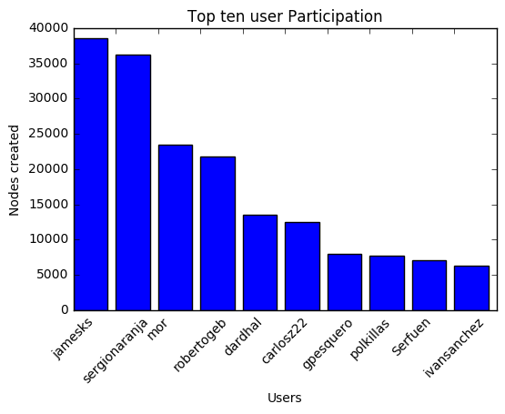

```python
hist = print_data(db, [{"$group":{"_id":"$created.user", "count": {"$sum": 1}}},{"$sort": {"count":-1}}, {"$limit":10}])
x = []
y = []
for elem in hist:
    aux = elem["count"]
    x.append(aux)
    y.append(elem["_id"])
%pylab inline
print x
order = [i for i in range(10)]
# we show a bar graph of the data for easier comprehension
fig, ax = plt.subplots()
ax.bar( order,x)
ax.set_xticks(order)
ax.set_title("Top ten user Participation")
ax.set_ylabel("Nodes created")
ax.set_xlabel("Users")
ax.set_xticklabels(y, rotation=45)
```

```python
# Now we are going to make a bar graph in which every bar will be a year so we first need to gather the data
hist = print_data(db, [{"$group":{"_id":"$created.timestamp", "count": {"$sum": 1}}},{"$sort": {"count":-1}}])
x = []
y = []
for elem in hist:
    aux = elem["count"]
    x.append(aux)
    y.append(elem["_id"])
year_rep = []
for elem in y:
    # we got the data and formatted to a datetime object so we can get the year
    aux = datetime.datetime.strptime(elem, "%Y-%m-%dT%H:%M:%SZ")
    year_rep.append(aux.year)
year = []
count = []
for elem in year_rep:
    if elem not in year:
        aux = 0
        for i in range(len(year_rep)):
            if elem == year_rep[i]:
                aux += x[i]
                x[i] = 0
        year.append(elem)
        count.append(aux)

print year
print count
```

```
[2006, 2007, 2008, 2009, 2010, 2011, 2012, 2013, 2014, 2015, 2016]
[27109, 16195, 24390, 23907, 27940, 45064, 32692, 12799, 41923, 4239, 100]
```

As you can see now we have two differen arrays that show aus the number of nodes created in each year, however the visualization of the data could be much better if the years were ordered. But we have another array that id dependant from the year so if we want to order one, we should order the other accordingly

```python
year_ordered = [y for (y,x) in sorted(zip(year,count))]
count_ordered = [x for (y,x) in sorted(zip(year,count))]
```

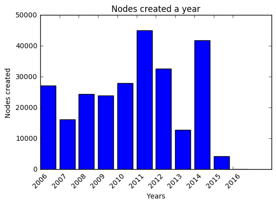

```python
%pylab inline
order = [i for i in range(len(year))]
fig, ax = plt.subplots()
ax.bar( order,count_ordered)
ax.set_xticks(order)
ax.set_title("Nodes created a year")
ax.set_ylabel("Nodes created")
ax.set_xlabel("Years")
ax.set_xticklabels(year_ordered, rotation=45)
```

At last we can see the ordered graph with the number of nodes created in the different years, as we can see the most active year was in 2011.

## Improving the data

The data we have been working with in theis project can be improved in a number of ways. I think the most important thing is to create a validation system before the new data is inputted. For example it will be nice if there would be some kind of validator that cloud check the format of the street phone and so on. In addition to the previous check there could be an enhancement that fills the missing information.

Another improvent could be an automatic validation of the inputted data based on the coordinates given. For example if you want to input some data for madrid the coordinates must be between some know parameters that form the area of madrid, so if the data we want to input its within this area is acepted. This coould help to avoid problems like the one I faced when I found a node of a bank that was hundreds of kilometers away from the area I choose to work with

As we saw in the previous graph the participation in 2015 was really low. In order to improve the participation the could be some kind of ranking system in which the users are not only ranked on the number of information inputted but also on the cleaningness and completeness of the data. This should encourage the users to input their data following as much as they can the style guides of OpenStreet Maps.

## Benefits and posible implementations on the data

One possible way of implementing the validation could be by involving all the user in the validation process, like if someone inputs the data, other people could validate it and get points for it so both their rankings improve. This could mean that the users will have the opportunity not only to increase their city with the inputted data but learn of new spots in their own cities or others thanks to the input of others. The ranking could give benefits when reach certain points. For example you can implement it as a point to unlock system. In which you start with one small area and once you start inputting data and earning point the area increases allowing you to access more area to input and validate. Also it could be stablished a rank or badge system, like once a month you can get a shareable badge that you could post in your social media to show your hard work and dedication. The implementation of the latter could be pretty easy, with just a program to check everyones participation numbers. The previous could require harder work but i im certain that it could be achievable

The automatic validation poses some programing difficulties given that there are multiple languages and in every language you have a distinct way of determine things like streettype or the postcode. In addition you got to face the problem of the encoding, which I faced during the project. Encoding can become really hard to face because in a city every node might not be in the same encoding due to the different user inputs.This should be in the style guide like for the cities or countries that in some cases need the use of special characters. All these countries texts should be all in the same encoding so you can operate with the need of parsing and avoiding unecessary errors in String handling.

## Conclusions

In conclusion we have worked with the entire city of Madrid, Spain in order to apply my knowledge of data analysis so we could audit, fix and enhance the city of Madrid, my hometown. Once we had our objective clear we set three different steps to acomplish our final result:

### Auditing:

in this step we searched for different ways of fixing or enhancing our data. I came up with different areas for enhancements:

- JSON format: we will be formatting everything to json for an easier handling
- Normalizing the street types: because there were multiple ways written
- Fixing errors: we found one human error of a node being in oru dataset where it shouldnt be
- Normalizing the phones: for an easier search and better visualization we should have all the phones with the same format
- Filling the missing data: we found some blanks in our data that could beneficiate if they were filled.

### Fixing:

In this step we took this tasks we found in the auditing part and applied them:

### Analyzing our data:

Once we had this batch of json documents auditted, fixed and enhanced we input them into our MongoDB database. Now that we have the collection database filled we can start working with it in order to get some important information out of it. With that goal in mind we draw two different bar graph in order to see what are the most important users, refering to node creation, and the most active years. Finally we wanted to work with different capabilities of the aggregate function and that is why we wanted to know which was the postcode with the most node referred to it.

### Conclusions

I have found two enhancements that could be appllied in the future:

- One thing we could add to our JSON is the difference city and autonomous community. Which in case you dont know the meaning of the term is the territorial division used in spain, for more information you can look it up here: https://en.wikipedia.org/wiki/Autonomous_communities_of_Spain
- Finish the code for the completion of the data. That involves letting the code run for as much as it needed to and spend some time re auditing the new data in order to be sure that the newly recieved data is up to our standards

To conclude I have been able to aduit, fix and analyze the data of the city of Madrid, Spain downloaded from OpenStreetMaps. During that I have been able to work with multiple libraries, from the handling of an .osm file to the requests library. Finally i used my knowledge of the mongoDB database calls in order to learn from the gathered data.

## Bibliography

- https://en.wikipedia.org/wiki/Autonomous_communities_of_Spain
- https://regex101.com/r/JJS2kz/1/tests
- http://stackoverflow.com/questions/10268518/python-string-to-unicode
- http://stackoverflow.com/questions/12559144/regex-for-fixed-position-and-length-field
- http://www.programmableweb.com/news/7-free-geocoding-apis-google-bing-yahoo-and-mapquest/2012/06/21
- http://api.mongodb.com/python/current/api/pymongo/collection.html?_ga=1.97754904.681387829.1477673030#pymongo.collection.Collection.insert_many
- http://stackoverflow.com/questions/1112343/how-do-i-capture-sigint-in-python
- http://stackoverflow.com/questions/6618515/sorting-list-based-on-values-from-another-list
- http://matplotlib.org/examples/api/barchart_demo.html
- http://stackoverflow.com/questions/19068269/how-to-convert-a-string-date-into-datetime-format-in-python
- https://geocode.xyz/api
- http://stackoverflow.com/questions/18836064/pymongo-method-of-getting-statistics-for-collection-byte-usage